# Data Translation Challenge

Author

Nishanth Sudhaharan

**AUDIENCE:** Sales Managers in a mobile dealership, who want some information on the sales pattern of the mobile phones that they sell on Amazon.

#### Amazon Sales Trend: Mobile Phones in 2019

The aim of this document is to analyze the trends in the sales of three mobile phones - iPhone, Google Pixel, and Vareebadd **in Amazon in 2019** and provide you with some interesting insights that I noticed. The pattern of sales of these products are **analyzed based their sales in random urban cities** and the quantities sold per day, every month in 2019.

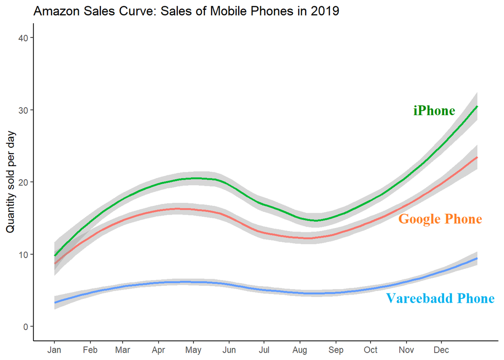

Yes, exactly, that is what the data says and it is pretty obviously understood looking at the visualization. But, what causes these increase/decrease in sales to occur? Are the reasons common to all three phones? Looks like we got much more analysis to do, right?

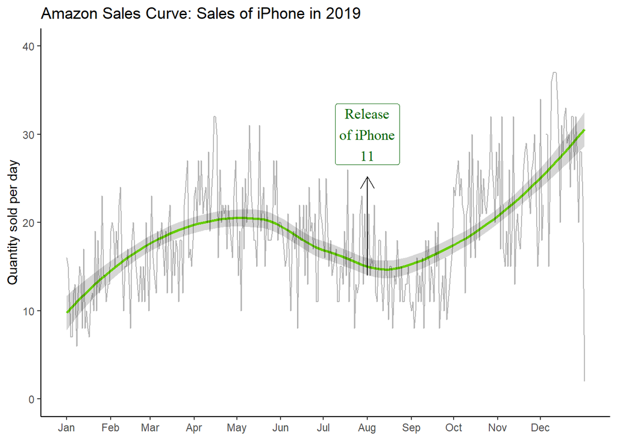

It is clear in the case of iPhones. We all know that Apple launches new mobile phones every year around August. From the visualization, it can be seen that the sales starts to drop as it comes close to the release of the Apple iPhone 11. It makes perfect sense because people might wait for a couple of months instead of buying a new phone that is going to be outdated in a month. After the iPhone 11 is released, the quantity of iPhones sold increases over the next months.

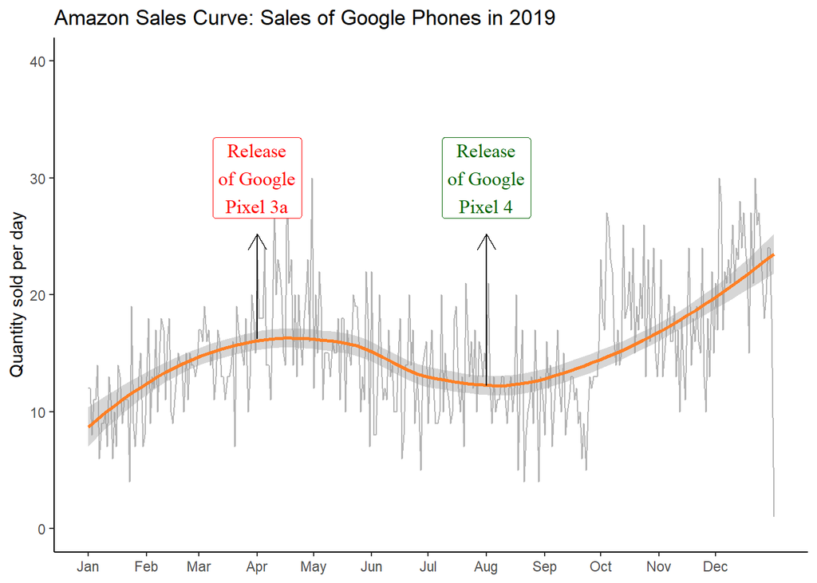

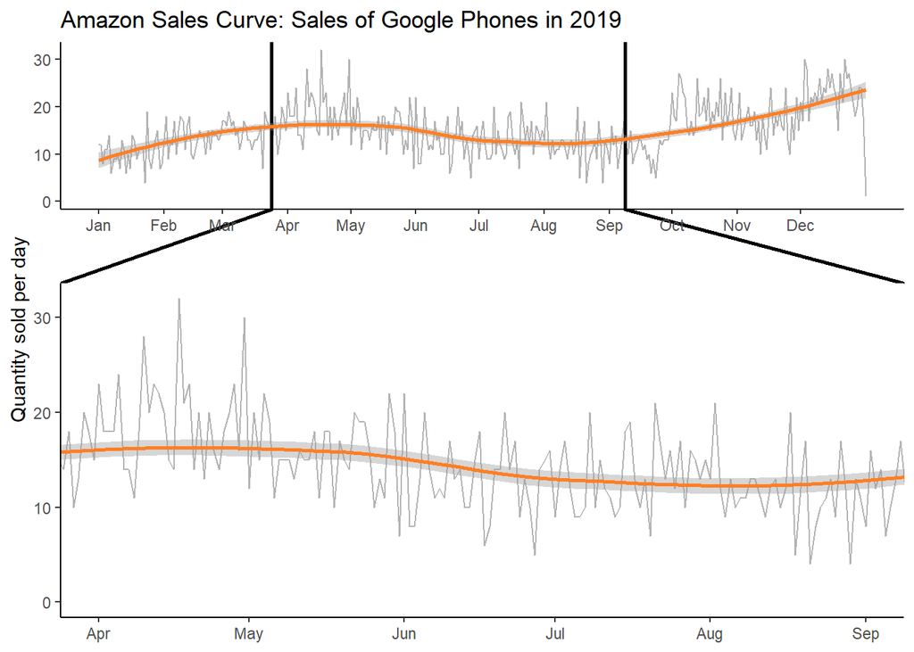

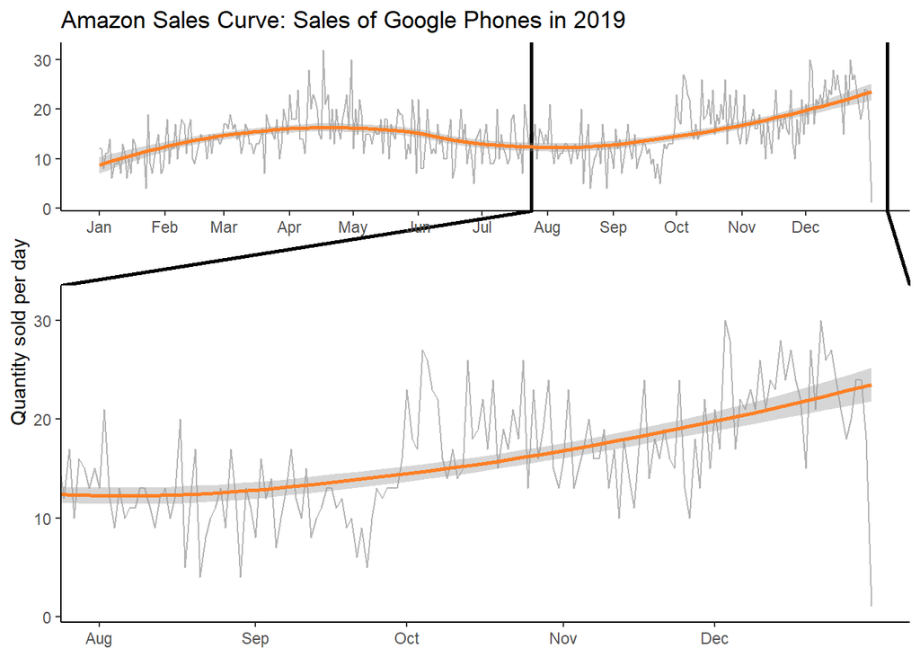

The declining sales in Google phones starts to develop in good ways after the release of Google Pixel 4. From being at around 10 products sold in these cities per day, it went up to 20 products being sold each day by the end of December. The sales doubled in numbers after August.

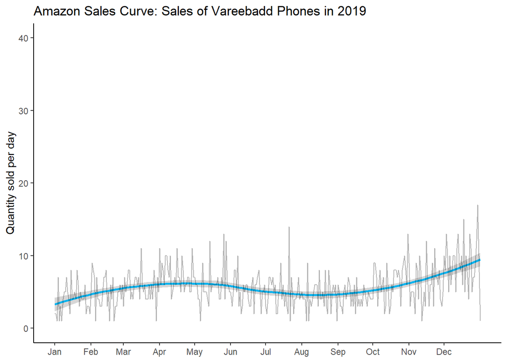

Although Vareebadd phones aren’t as common as iPhones and Google phones in these cities, it is really interesting that even it followed the similar pattern in sales as the other two phones in 2019. The sales drops in the summer and starts to increase in August.

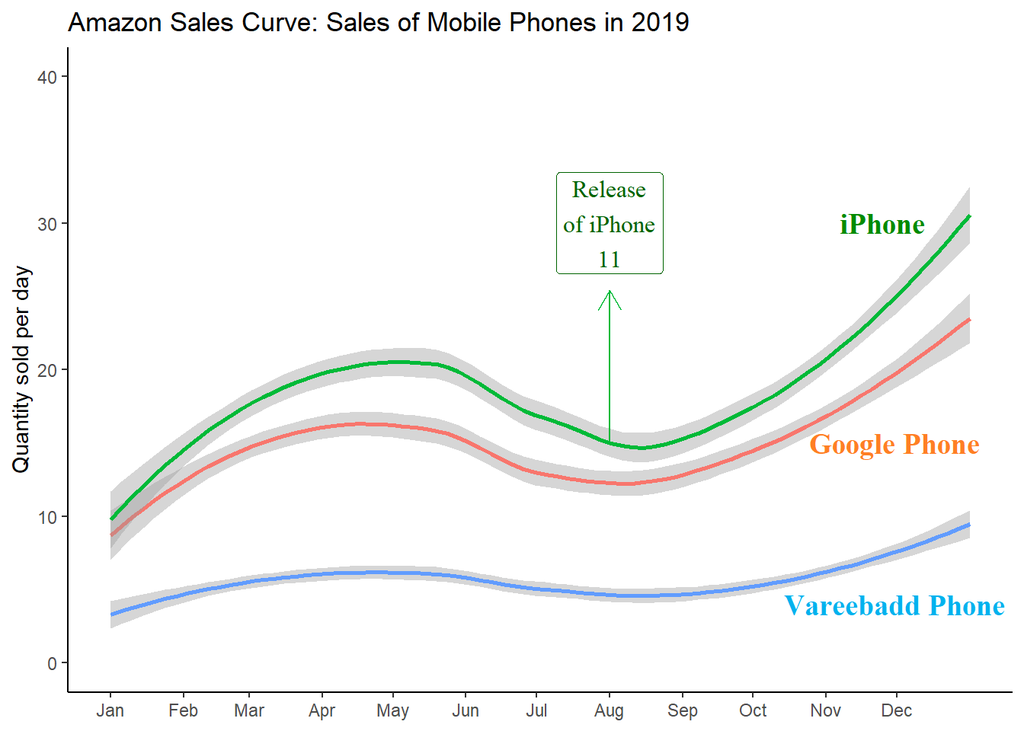

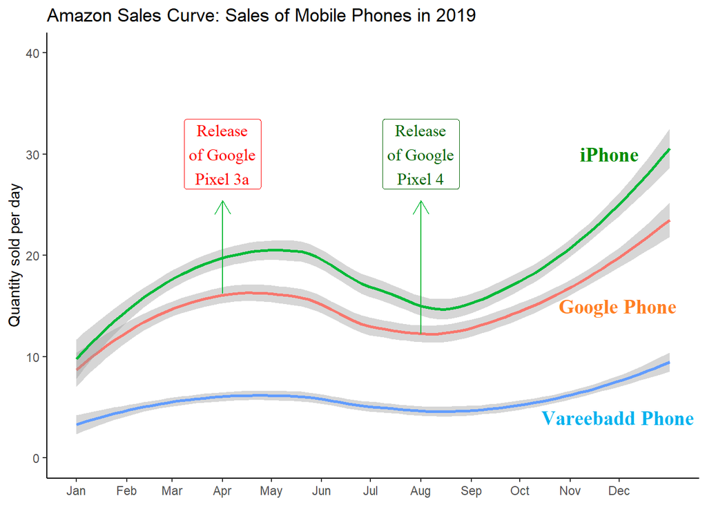

From the visualizations, we can understand that the launch of a newer version of the product affects the sales of the existing product in the months nearing the launch. People tend to buy the product more when a newer version is available, thus, increasing the sales of the particular product. In order to avoid the drop in sales during periods like these, the prices of the products can be reduced, additional offers or gifts can be provided to promote sales during the dry period until the launch of the latest model.